# Week04 - Interactive and Configurable Parallel Coordinates

January 30, 2015

## htmlwidgets News This Week

@kbroman starts exploring `htmlwidgets`.

-[@kbroman](https://github.com/kbroman/testjs) - test `htmlwidgets` conversion of the scatterplot from his [`qtlcharts`](http://kbroman.org/qtlcharts/)

@rich-iannone

[@rich-iannone] - [`DiagrammeR`](https://github.com/rich-iannone/DiagrammeR) hits version 0.4 with full shiny support and `graphviz`, gets a [webpage](http://rich-iannone.github.io/DiagrammeR/) (thanks JJ Allaire), and becomes the first `htmlwidget` to surpass 100 stars on Github.

## This Week’s Widget - `parcoords` | Interactive d3.js Parallel Coordinates

Real quickly before I get to this week’s widget, I would like to strongly encourage anyone who likes any of the widgets to let me know through stars/forks on Github, [twitter](http://twitter.com/timelyportfolio), comments on blog, or posts/examples/rpubs using the widget. It helps me prioritize which to keep alive and improve and also motivates me to continue building more.

By far, one of my favorite reusable `d3` charts is the parallel-coordinates project by [@syntagmatic](https://github.com/syntagmatic). Its unique combination of `SVG` and `canvas` quickly digests even large (big for me) datasets while still maintaining easy but powerful interactivity for exploring the data at a high level, inspecting more granular visible features, and determining additional areas for inquiry. I also just think there is something really cool and compelling about it.

## What Does it Do?

This paper [*Ranking Visualization of Correlation using Weber’s Law*](http://www.cs.tufts.edu/~remco/publications/2014/InfoVis2014-JND.pdf) presented at InfoVis 2014 compares multiple chart types for their effectiveness in conveying correlation. As seen in the image from the paper below, parallel coordinates charts rate very highly, especially in negative correlation relationships.

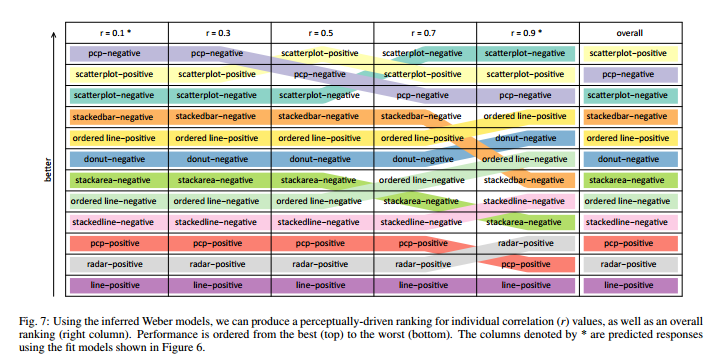

Ok, enough discussion let’s move on to the examples, since I think most speak for themselves.

### Simple Example

```r
# not on CRAN, so install with devtools
#  devtools::install_github("timelyportfolio/parcoords")
library(parcoords)

data(mtcars)

# just plain old stock parallel coordinates
#   don't worry its easy to make a whole lot better
parcoords( mtcars )
```

[interactive chart not shown]

If you are familiar with `MASS` function `parcoord`, I’m sure you are not that impressed, so we’ll turn on some interactivity in the next example.

### Brush On and Reorder

Two of interactive behaviors provided by `parallel-coordinates` are a brush to filter data and reorderable axes. Try both of these in this revised version of the above example.

```r
parcoords(
  mtcars
  , brush = "1d-axes" # 2d-strums are really neat
  , reorderable = TRUE
)
```

[interactive chart not shown]

### Queue Render for Bigger Data and Some Color

`parallel-coordinates` handles bigger data well since the lines are drawn on the `canvas`. Set `queue = T` to progressively render the chart on build and interaction. Here is one [example](http://syntagmatic.github.io/parallel-coordinates/index.html#example-progressive) and [another](http://syntagmatic.github.io/parallel-coordinates/examples/slickgrid.html) from the `parallel-coordinates` site. The `diamonds` dataset from `ggplot2` will give us big enough data to test the progressive render and prove that we are in `R`. I’ll sample the `diamonds` to reduce the size of the HTML, but feel free to remove the sample and use the entire dataset on your local machine.

```r
data( diamonds, package = "ggplot2" )
parcoords(
  diamonds[sample(1:nrow(diamonds),1000),]
  , rownames = F # turn off rownames from the data.frame
  , brushMode = "2D-strums"
  , reorderable = T
  , queue = T
  , color = RColorBrewer::brewer.pal(4,"BuPu")[4]
)
```

[interactive chart not shown]

I hope you noticed the fancy new brush type. I would improve the chart by using color to represent the data. Let’s try a little more complicated color specification using the color helper from `d3.scale.category10()`. For even more fun let’s put it in a `dplyr` chain.

```r
library(dplyr)
diamonds[sample(1:nrow(diamonds),1000),] %>%
  mutate( carat = cut(carat, breaks=c(0,1,2,3,4,5), right = T)) %>%
  select( carat, color, cut, clarity, depth, table, price,  x, y, z) %>%
  parcoords(
    rownames = F # turn off rownames from the data.frame
    , brushMode = "2D-strums"
    , reorderable = T
    , queue = T
    , color = list(
      colorBy = "carat"
      ,colorScale = htmlwidgets::JS("d3.scale.category10()")
    )
  )
```

[interactive chart not shown]

While we are on the topic of color, I wanted to highlight the fine work by Gregor Aisch with chroma.js and palettes. We could use Jeroen Oom’s new `V8` for this, but for now, let’s stick with what we have in `R` and `d3.js` using a `d3.scale.threshold` with colors supplied by `RColorBrewer::brewer.pal`.

```r
diamonds[sample(1:nrow(diamonds),1000),] %>%
  select( carat, color, cut, clarity, depth, table, price,  x, y, z) %>%
  parcoords(
    rownames = F # turn off rownames from the data.frame
    , brushMode = "2D-strums"
    , reorderable = T
    , queue = T
    , color = list(
      colorBy = "carat"
      ,colorScale = htmlwidgets::JS(sprintf('
        d3.scale.threshold()
          .domain(%s)
          .range(%s)
        '
        ,jsonlite::toJSON(seq(0,round(max(diamonds$carat))))
        ,jsonlite::toJSON(RColorBrewer::brewer.pal(6,"PuBuGn"))
      ))
    )
  )
```

[interactive chart not shown]

## Unfinished

Well, I hope that gives you enough to get started and gauge your interest. **This is unfinished with lots of potential for helpful refinements. Please let me know if you would like me to push ahead.**

## Thanks

Thanks so much for all the work by

- [Mike Bostock](http://bost.ocks.org/mike/)
- [Kai Chang](https://github.com/syntagmatic)
- [Hadley Wickham](https://github.com/hadley) for `testthat`
- Ramnath Vaidyanathan and RStudio for `htmlwidgets`